# Chapter 17

Alan T. Arnholt

Last compiled: February 21, 2022 at 06:53:43 PM

# 1 Confidence Intervals for Means

**Objectives:**

1. Discover the sampling distribution of $\bar{x}$
2. Use the distribution to solve problems
3. $t$ distribution
4. Examples of CI for $\mu$
5. Special conditions for $t$

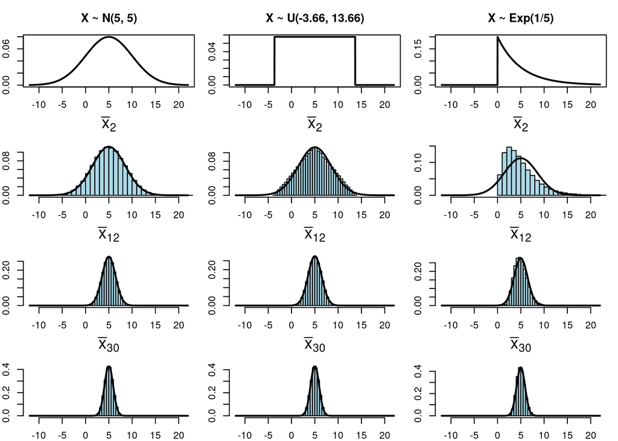

```
         [,1]      [,2]     [,3]      [,4]     [,5]      [,6]
[1,] 5.001683 3.5554771 4.994494 3.5352382 4.989162 3.5278757
[2,] 5.003822 1.4392532 5.006902 1.4433385 4.999879 1.4400580
[3,] 5.005403 0.9126828 5.002752 0.9129279 5.004282 0.9107622
```

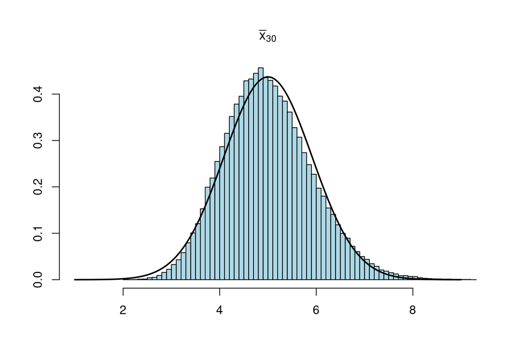

```r
m <- 100000  # Number of Samples
EX <- 1.1   # Character expansion
COLOR = "lightblue"
xbar.30 <- apply(matrix(rexp(m*30,1/5),nrow=m),1,mean)
e30 <- c(mean(xbar.30), sd(xbar.30))
hist(xbar.30, breaks = 70, col = COLOR, xlim=c(1, 9), prob=TRUE, xlab="", ylab="", main="")
mtext(expression(bar(x)[30]), side = 3, line = 1,cex = EX)
curve(dnorm(x, 5, 5/sqrt(30)), add = TRUE, n = 300, lwd = 2)
```

If $n$ is “large enough” and sampled values are independent, $\bar{x} \dot\sim \mathcal{N}\left(\mu_{\bar{x}} = \mu, \sigma_{\bar{x}} = \frac{\sigma}{\sqrt{n}} \right)$

**Conditions:**

> **The Central Limit Theorem** states that as $n$ increases, the sample mean has a more and more normal shaped sampling distribution with the same mean as the population and a standard deviation of $\sigma/\sqrt{n}$.

## 1.1 Example

Wildlife scientists studying a certain species of frogs know that adults should weigh an average of 118 grams with a standard deviation of 14 grams.

1. What is the distribution of $\bar{x}$?

**ANSWER:** $\bar{x} \sim \mathcal{N}(118, 14/\sqrt{50} = 1.979899)$

2. A random sample of 50 adult frogs gives a mean weight of only 110 grams, Is this unusually low?

**ANSWER:**

3. What percent of similar samples would have average weights less than 112 grams?

$P(\bar{x}\leq 112)=$?

```r
# Your code here
```

4. Between 115 and 120 grams?

$P(115 \leq \bar{x} \leq 120)=$?

```r
# Your code here
```

5. More than 125 grams?

$P(\bar{x} \geq 125)=$?

```r
# Your code here
```

6. What is the 5$^{\text{th}}$ percentile of average from weight when $n = 50$?

$P(\bar{x} \leq q) = 0.05\rightarrow q = 114.743356$?

```r
# Your code here
```

Problem with the normal distribution is that we seldom know the value of $\sigma$!

What happens when $\sigma$ is replaced with $s$ in $\frac{(\bar{X} - \mu)}{\sigma/\sqrt{n}}$?

$$\frac{(\bar{X} - \mu)}{s/\sqrt{n}} \sim t_{n-1}$$

$$f(t) = \frac{\Gamma(\frac{\nu + 1}{2})}{\sqrt{\nu\pi}\cdot\Gamma(\frac{\nu}{2})}\left(1 + \frac{t^2}{\nu} \right)^{-\tfrac{\nu+1}{2}}$$
where $\nu =$ df, $\Gamma(n) = (n - 1)!$, $\Gamma(\frac{1}{2}) = \sqrt{\pi}$, and $\Gamma(x)=\int_{0}^{\infty}t^{x -1}e^{-t}dt$

**To use a $t-$distribution, sample size determines what to check**

$n < 20$ check that sample is enarly normal; $20 \leq n < 30$ sample should have no outliers, some skewness OK; $n \geq 30$ sample should not have strong skewnss or far outliers.